# Tugas Praktikum 2

Data Wrangling dan Data Visualization

Author

Thariq Irza - M0501261075  
Angelina - M0501261007  
Ratu Ajeng Fadila Husen - M0501261091

Published

September 15, 2026

# 1 Data Wrangling Pembersihan Data Mahasiswa

## 1.1 Dataframe

```r
nilai_raw <- data.frame(
    Nama = c('Andi','Budi','Citra', 'Dewi', 'Andi'),
    Nilai = c(80,90,NA,75,80),
    Statistika = c(85,88,78,"-",85),
    Umur= c(21,22,20,21,21))

nilai_raw
```

```
   Nama Nilai Statistika Umur
1  Andi    80         85   21
2  Budi    90         88   22
3 Citra    NA         78   20
4  Dewi    75          -   21
5  Andi    80         85   21
```

## 1.2 Nilai hilang dan Transformasi tanda hubung

```r
# Identifikasi nilai hilang
sum_isna <- function(df) {
  sum(is.na(df))}
sum_isna(nilai_raw)
```

```
[1] 1
```

```r
#Transformasi tanda hubung menjadi NA
nilai_raw[,'Statistika'] = as.numeric(gsub("-", "NA", nilai_raw$Statistika))
```

```r
# Identifikasi kembali nilai hilang
sum_isna <- function(df) {
  sum(is.na(df))}
sum_isna(nilai_raw)
```

```
[1] 2
```

**Note**

Pada proses pertama identifikasi nilai hilang, hanya terdapat 1 nilai hilang (NA) dari dataset. Namun pada dataframe sendiri terdapat nilai hilang yang disimbolkan dengan tanda hubung (-) sehingga dilakukan perubahan format dari tanda hubung (-) menjadi nilai NA. Sehingga terdapat 2 nilai hilang setelah dilakukan identifikasi kembali

## 1.3 Imputasi data NA pada kolom Statistika

```r
# Imputasi data NA dengan nilai mean pada kolom Statistika
nilai_raw$Statistika <- ifelse(is.na(nilai_raw$Statistika), mean(nilai_raw$Statistika, na.rm = TRUE), nilai_raw$Statistika)
nilai_raw
```

```
   Nama Nilai Statistika Umur
1  Andi    80         85   21
2  Budi    90         88   22
3 Citra    NA         78   20
4  Dewi    75         84   21
5  Andi    80         85   21
```

## 1.4 Kategori Umur

```r
nilai_raw$Status_Umur <- ifelse(
  nilai_raw$Umur < 21,
  "Muda",
  "Dewasa"
)
nilai_raw
```

```
   Nama Nilai Statistika Umur Status_Umur
1  Andi    80         85   21      Dewasa
2  Budi    90         88   22      Dewasa
3 Citra    NA         78   20        Muda
4  Dewi    75         84   21      Dewasa
5  Andi    80         85   21      Dewasa
```

## 1.5 Hapus duplikat

```r
nilai_raw <- unique(nilai_raw)
nilai_raw
```

```
   Nama Nilai Statistika Umur Status_Umur
1  Andi    80         85   21      Dewasa
2  Budi    90         88   22      Dewasa
3 Citra    NA         78   20        Muda
4  Dewi    75         84   21      Dewasa
```

## 1.6 Save data

```r
write.csv(nilai_raw, 'nilai_bersih.csv', row.names = FALSE)
```

# 2 Subset dan Sort Multicriteria

## 2.1 Dataframe

```r
profil <- data.frame(
    gender = c(rep("f", 3), rep("m",2), "f",rep("m",2), "f","m"),
    v1= c(8,15,8,14,8,10,9,9,10,12),
    v2= c(9,8,13,9,2,6,9,10,13,10),
    v3= c(5,9,12,8,9,10,7,8,6,9),
    v4= c(9,5,6,NA,16,9,13,10,7,8),
    v5= c(9,10,7,11,8,10,9,5,10,17),
    v6= c(9,8,9,10,10,10,12,10,12,7),
    v7= c(5,10,14,6,8,9,10,6,13,9),
    v8= c(9,12,12,11,9,7,9,12,9,10),
    v9= c(11,9,12,11,8,7,11,6,6,7),
    v10= c(8,15,9,8,9,11,7,8,9,7)
)
profil
```

```
   gender v1 v2 v3 v4 v5 v6 v7 v8 v9 v10
1       f  8  9  5  9  9  9  5  9 11   8
2       f 15  8  9  5 10  8 10 12  9  15
3       f  8 13 12  6  7  9 14 12 12   9
4       m 14  9  8 NA 11 10  6 11 11   8
5       m  8  2  9 16  8 10  8  9  8   9
6       f 10  6 10  9 10 10  9  7  7  11
7       m  9  9  7 13  9 12 10  9 11   7
8       m  9 10  8 10  5 10  6 12  6   8
9       f 10 13  6  7 10 12 13  9  6   9
10      m 12 10  9  8 17  7  9 10  7   7
```

## 2.2 Subset

```r
kondisi_profil <- (profil$gender == 'm' & profil$v1 > 9) | (profil$gender == 'f' & profil$v3 <= 10)
profil_subset <- profil[kondisi_profil, ]
profil_subset
```

```
   gender v1 v2 v3 v4 v5 v6 v7 v8 v9 v10
1       f  8  9  5  9  9  9  5  9 11   8
2       f 15  8  9  5 10  8 10 12  9  15
4       m 14  9  8 NA 11 10  6 11 11   8
6       f 10  6 10  9 10 10  9  7  7  11
9       f 10 13  6  7 10 12 13  9  6   9
10      m 12 10  9  8 17  7  9 10  7   7
```

## 2.3 Sort Multicriteria

```r
# Urutkan gender (descending) lalu v5 (ascending)
profil_filter <- profil_subset[order(-as.integer(factor(profil_subset$gender)), profil_subset$v5), ]
profil_filter
```

```
   gender v1 v2 v3 v4 v5 v6 v7 v8 v9 v10
4       m 14  9  8 NA 11 10  6 11 11   8
10      m 12 10  9  8 17  7  9 10  7   7
1       f  8  9  5  9  9  9  5  9 11   8
2       f 15  8  9  5 10  8 10 12  9  15
6       f 10  6 10  9 10 10  9  7  7  11
9       f 10 13  6  7 10 12 13  9  6   9
```

## 2.4 Save Data

```r
write.csv(profil_filter, 'profil_filter.csv', row.names = FALSE)
```

# 3 Penggabungan dan Reshaping Data

## 3.1 Merge Dataframe

```r
df_sales <- data.frame(
  id_toko = c("T1", "T2", "T3"),
  Minggu1 = c(120, 150, 95),
  Minggu2 = c(135, 140, 110)
)

df_info <- data.frame(
  id = c("T1", "T2", "T4"),
  Kota = c("Jakarta", "Bandung", "Surabaya")
)

gabung <- merge(df_sales, df_info, by.x="id_toko", by.y = "id", all=TRUE)

gabung
```

```
  id_toko Minggu1 Minggu2     Kota
1      T1     120     135  Jakarta
2      T2     150     140  Bandung
3      T3      95     110     <NA>
4      T4      NA      NA Surabaya
```

## 3.2 Reshape Penggabungan

```r
gabung_long <- reshape(
  gabung,
  varying = c("Minggu1", "Minggu2"),
  v.names = "Penjualan",
  timevar = "Waktu",
  times = c("Minggu1", "Minggu2"),
  idvar = "id_toko",
  direction = "long"
)
rownames(gabung_long) <- NULL
gabung_long
```

```
  id_toko     Kota   Waktu Penjualan
1      T1  Jakarta Minggu1       120
2      T2  Bandung Minggu1       150
3      T3     <NA> Minggu1        95
4      T4 Surabaya Minggu1        NA
5      T1  Jakarta Minggu2       135
6      T2  Bandung Minggu2       140
7      T3     <NA> Minggu2       110
8      T4 Surabaya Minggu2        NA
```

## 3.3 Save Data

```r
write.csv(gabung_long, 'penjualan_long.csv', row.names = FALSE)
```

# 4 Eksplorasi Visual

## 4.1 Scatterplot CO2 dan beberapa variabel lain

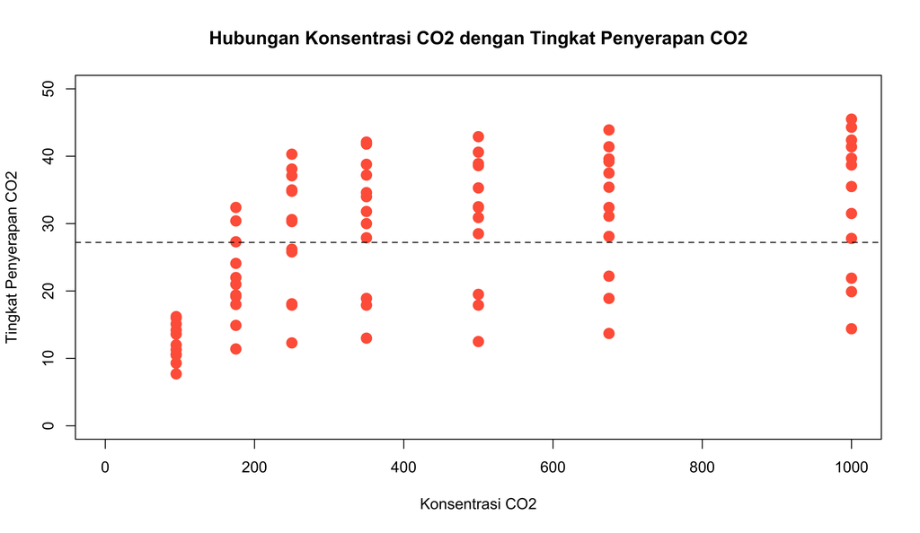

```r
library(ggplot2)
plot(x = CO2$conc, y = CO2$uptake,
     type = "p", pch = 19, cex = 1.5, col= "Tomato", main = "Hubungan Konsentrasi CO2 dengan Tingkat Penyerapan CO2", xlab = "Konsentrasi CO2", ylab = "Tingkat Penyerapan CO2", xlim = c(0,1000), ylim = c(0,50))
abline(h = mean(CO2$uptake), lty=2)
```

## 4.2 Canvas 2X2

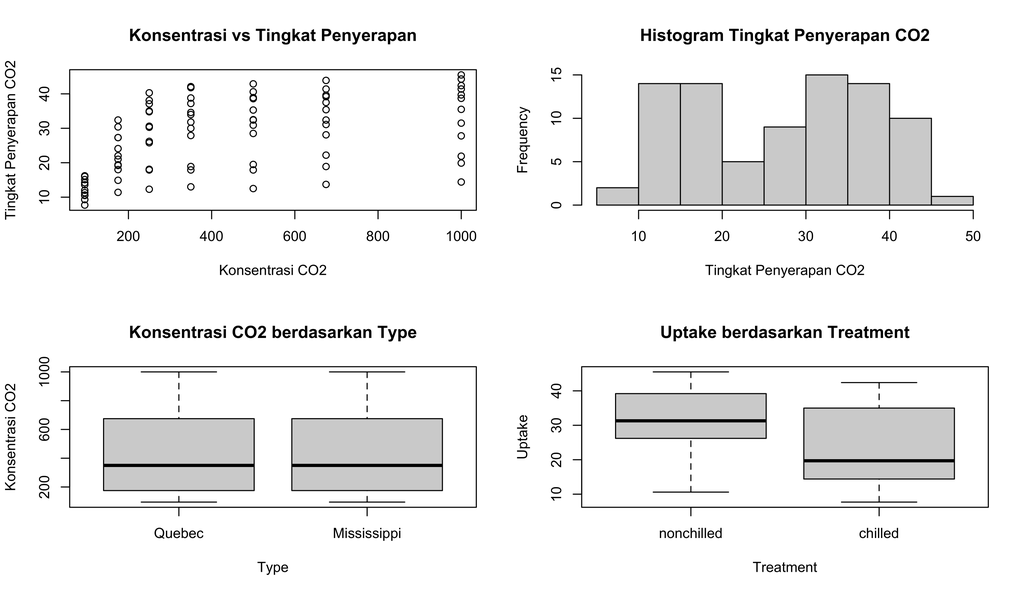

```r
par(mfrow = c(2, 2))

plot(x = CO2$conc, y = CO2$uptake, main = "Konsentrasi vs Tingkat Penyerapan", xlab = "Konsentrasi CO2", ylab = "Tingkat Penyerapan CO2")
hist(CO2$uptake, main = "Histogram Tingkat Penyerapan CO2", xlab = "Tingkat Penyerapan CO2")
boxplot(CO2$conc ~ CO2$Type, main = "Konsentrasi CO2 berdasarkan Type", xlab = "Type", ylab = "Konsentrasi CO2")
boxplot(CO2$uptake ~ CO2$Treatment, main = "Uptake berdasarkan Treatment", xlab = "Treatment", ylab = "Uptake")
```

## 4.3 Qplot dan GGplot2

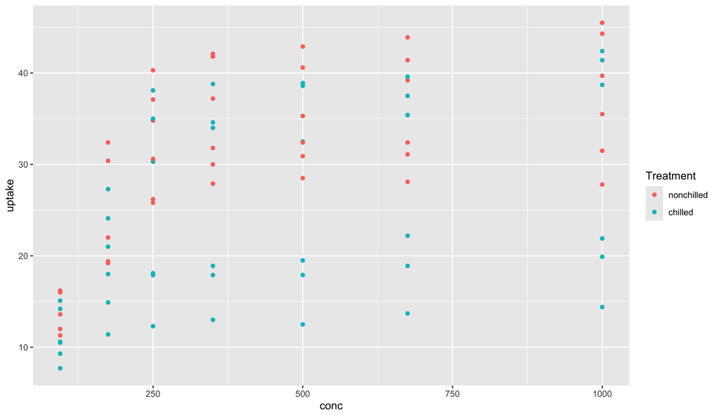

```r
library(ggplot2)
qplot(
  x = conc,y = uptake,
  data = CO2, color = Treatment, geom= "point"
)
```

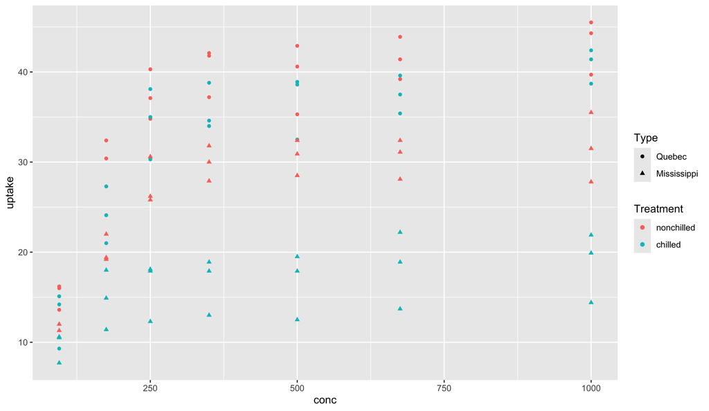

```r
ggplot(CO2,
  aes(x = conc, y = uptake, color = Treatment, shape = Type)
) +
  geom_point()
```

## 4.4 Pengembangan GGplot2

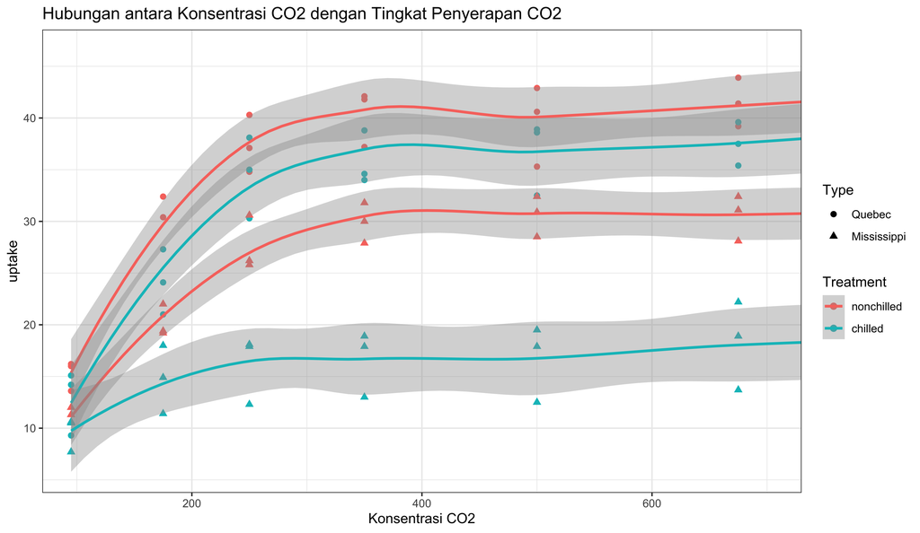

```r
ggplot(CO2,
  aes(x = conc, y = uptake, color = Treatment, shape = Type)
) +
  geom_point(size = 2)+
  scale_x_continuous(name = "Konsentrasi CO2")+
  stat_smooth()+
  coord_cartesian(xlim=c(100,700))+
  labs(title = "Hubungan antara Konsentrasi CO2 dengan Tingkat Penyerapan CO2")+
  theme_bw()
```

**Note**

Berdasarkan grafik yang dihasilkan, dapat dilihat bahwa `konsentrasi CO2 (conc)` dan `tingkat penyerapan CO2 (uptake)` memiliki hubungan yang cenderung **positif**. Ketika `konsentrasi CO2 (conc)` **meningkat**, nilai `tingkat penyerapan CO2 (uptake)` pada tanaman secara umum juga **meningkat**. Namun, pada **konsentrasi yang lebih tinggi** (setelah konsentrasi CO2 berada di sekitar 350), peningkatan `tingkat penyerapan CO2` mulai terlihat lebih **lambat** dan cenderung **konstan**, sehingga hubungannya tidak sepenuhnya **linear**.

Berdasarkan `Type` dan `Treatment`, terlihat bahwa terdapat perbedaan pola penyerapan antar kelompok tanaman. Kelompok `Type` yang berbeda (*Quebec* dan *Mississipi*) menunjukkan `tingkat penyerapan CO2` yang berbeda. Jika dilihat sekilas `Type Quebec (bentuk titik)` cenderung memiliki `tingkat penyerapan CO2` yang lebih **tinggi** dari `Type Mississipi (bentuk segitiga)`.

Begitu pula dengan `Treatment` yang menunjukkan perbedaan pola yang dapat dilihat dari warna titik pada grafik. Tanaman dengan `Treatment nonchilled (warna pink)` cenderung memiliki tingkat penyerapan CO2 yang lebih tinggi daripada Tanaman dengan `Treatment chilled (warna biru)`.

Meskipun demikian, berdasarkan kelompok tersebut secara umum tetap menunjukkan kecenderungan bahwa semakin **tinggi** `konsentrasi CO2 (conc)`, semakin **tinggi** pula `tingkat penyerapan CO2 (uptake)`. Hal ini menunjukkan bahwa pola `tingkat penyerapan CO2` tidak hanya berbeda berdasarkan konsentrasi CO2, tetapi juga berdasarkan `Type` dan `Treatment`.

## 4.5 Save Picture

```r
ggsave("co2_uptake_visualisasi.png")
```